# QTM151 Group Project: How does the prevalence of quality of rights measures in different countries move with the GDP?

## We further break our analysis into high and low/mid income countries to study the correlation differences base on income levels.

```python
import matplotlib.pyplot as plt
import pandas as pd
import numpy as np
import seaborn as sns
import matplotlib.patches as mpatches
from scipy.stats import linregress
```

```python
# Load the datasets
civil_political_right=pd.read_csv("csv files/cpr.csv")
High_Income_Global=pd.read_csv("csv files/esr_hiy_globalbest.csv")
Low_Mid_Income_Global=pd.read_csv("csv files/esr_lmy_globalbest.csv")
High_Income_Adjusted=pd.read_csv("csv files/esr_hiy_incomeadjusted.csv")
Low_Mid_Income_Adjusted=pd.read_csv("csv files/esr_lmy_incomeadjusted.csv")
Sex=pd.read_csv("csv files/esr_sex_disaggregated.csv")
Ppl_risk=pd.read_csv("csv files/people_at_risk.csv")
Pacific_Taiwan=pd.read_csv("csv files/Pacific_Taiwan_data.csv",encoding='ISO-8859-1')
```

### Subsection 1: How Income Levels Relate to Health and GDP

This chart compares two things between countries with different income levels: their average performance on health rights and their average income per person.

- The **left plot** shows the average **health rights score** for each group. This score reflects how well countries are doing at meeting basic health needs—like making sure people survive into adulthood, children live past age five, and people have access to medical care.
- The **right plot** shows the average **GDP per capita** (gross domestic product per person), which is a common way of measuring how wealthy a country is.

There are two colored bars for each plot:

- The **teal bars** show the average for **low and middle income countries**
- The **gray bars** show the average for **high income countries**

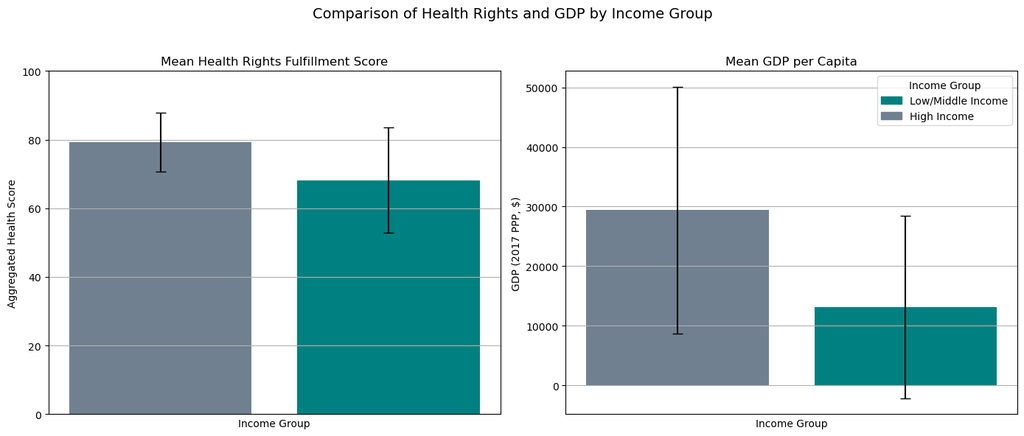

```python
# Use appropriate GDP proxies from survival indicators
lmy_health = Low_Mid_Income_Global[['Country', 'LMY_Health_All_GBScore', 'AdultSurvival_All_MRGDP']].dropna()
hiy_health = High_Income_Global[['Country', 'HiY_Health_All_GBScore', 'SeniorSurvival_All_MRGDP']].dropna()

# Rename for consistency
lmy_health.columns = ['Country', 'HealthScore', 'GDP']
hiy_health.columns = ['Country', 'HealthScore', 'GDP']

# Add income group labels
lmy_health['IncomeGroup'] = 'Low/Middle Income'
hiy_health['IncomeGroup'] = 'High Income'

# Combine datasets
combined_health_df = pd.concat([lmy_health, hiy_health], ignore_index=True)

# Calculate mean and standard deviation for GDP and HealthScore by income group
summary_df = combined_health_df.groupby('IncomeGroup').agg(
    Mean_HealthScore=('HealthScore', 'mean'),
    Std_HealthScore=('HealthScore', 'std'),
    Mean_GDP=('GDP', 'mean'),
    Std_GDP=('GDP', 'std')
).reset_index()

# Create side-by-side bar plots using matplotlib
fig, axes = plt.subplots(1, 2, figsize=(14, 6), sharex=False)

# Plot 1: Aggregated Health Rights Fulfillment Score
x = np.arange(len(summary_df['IncomeGroup']))

colors = ['slategray', 'teal']  # for the legend
income_groups = summary_df['IncomeGroup']

axes[0].bar(x, summary_df['Mean_HealthScore'], yerr=summary_df['Std_HealthScore'], capsize=5, color=colors)
axes[0].set_title('Mean Health Rights Fulfillment Score')
axes[0].set_xlabel('Income Group')
axes[0].set_ylabel('Aggregated Health Score')
axes[0].set_xticks([])
axes[0].set_ylim(0, 100)
axes[0].grid(axis='y')

# Plot 2: GDP per Capita
axes[1].bar(x, summary_df['Mean_GDP'], yerr=summary_df['Std_GDP'], capsize=5, color=colors)
axes[1].set_title('Mean GDP per Capita')
axes[1].set_xlabel('Income Group')
axes[1].set_ylabel('GDP (2017 PPP, $)')
axes[1].set_xticks([])
axes[1].grid(axis='y')

# Adding legend
legend_patches = [
    mpatches.Patch(color=colors[1], label='Low/Middle Income'),
    mpatches.Patch(color=colors[0], label='High Income')
]
axes[1].legend(handles=legend_patches, title='Income Group', loc='upper right')

# Adding a title to the entire figure and showing the plot
plt.suptitle('Comparison of Health Rights and GDP by Income Group', fontsize=14)
plt.tight_layout(rect=[0, 0, 1, 0.95])
plt.show()
```

### Summary: From the chart, it’s clear that high income countries score higher on both health and economic indicators. In other words, countries with more money (or a higher GDP) tend to do a better job of ensuring people’s health rights are met. This does not mean every rich country is perfect or every poorer country fails—but on average, income and health rights tend to rise together.

### Subsection 2: The relationship between housing scores and GDP

- The following code will analyze the relationship between GDP per capita and housing scores for high-income and low/mid-income countries in 2021.
- We specifically look at the most recent year available (2021) for each country in the dataset.

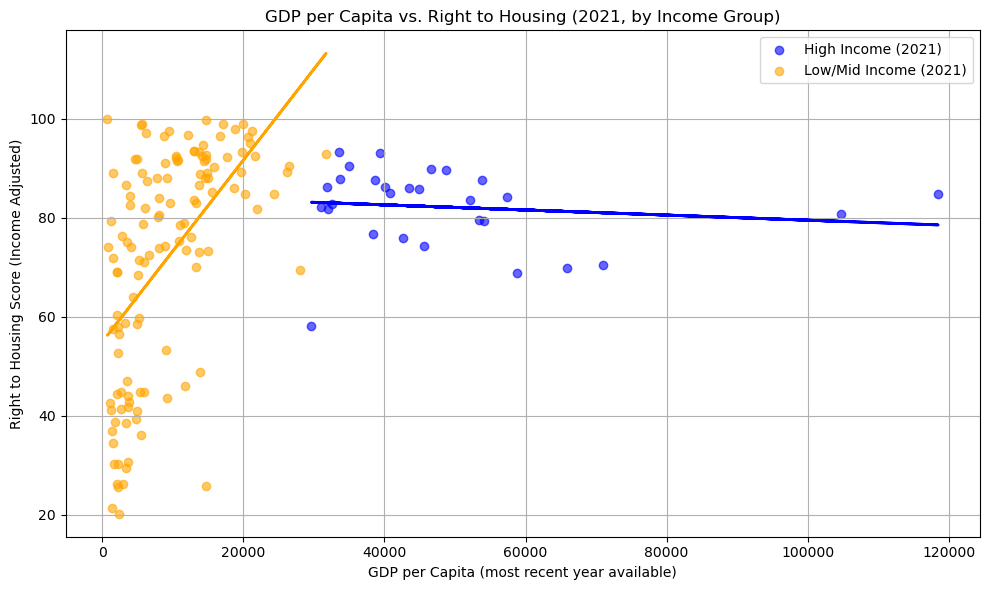

```python
# Step 1: Access housing scores for high-income and low/mid-income countries using the High_Income_Adjusted and Low_Mid_Income_Adjusted datasets.
# create new datasets'housing_hiy' and 'housing_lmy'.

housing_hiy = High_Income_Adjusted[
    (High_Income_Adjusted['High_Income_Country'] == 1) # Select rows with a 1 for high-income countries in the 'High_Income_Country' column of the High_Income_Adjusted dataset.
][['Country', 'Year', 'HiY_Housing_All_IAScore', 'U5Survival_All_MRGDP']] # Filter the datasets to include only the relevant columns: 'Country', 'Year', 'Housing_Score', and 'GDP_per_capita'.

housing_lmy = Low_Mid_Income_Adjusted[
    (Low_Mid_Income_Adjusted['High_Income_Country'] == 0) # Select rows with a 0 for high-income countries in the 'High_Income_Country' column of the Low_Mid_Income_Adjusted dataset.
][['Country', 'Year', 'LMY_Housing_All_IAScore', 'U5Survival_All_MRGDP']] # Filter the datasets to include only the relevant columns: 'Country', 'Year', 'Housing_Score', and 'GDP_per_capita'.

# Step 2: Rename columns for consistency
housing_hiy = housing_hiy.rename(columns={
    'HiY_Housing_All_IAScore': 'Housing_Score',
    'U5Survival_All_MRGDP': 'GDP_per_capita'
})
housing_lmy = housing_lmy.rename(columns={
    'LMY_Housing_All_IAScore': 'Housing_Score',
    'U5Survival_All_MRGDP': 'GDP_per_capita'
})

# Step 3: Add income group label
housing_hiy['Income_Group'] = 'High Income'
housing_lmy['Income_Group'] = 'Low/Mid Income'

# Step 4: Combine both datasets
housing_df = pd.concat([housing_hiy, housing_lmy], ignore_index=True)

# Step 5: Clean the data by removing rows with missing values and infinite values
housing_df = housing_df.replace([float('inf'), -float('inf')], pd.NA).dropna()

# Step 6: Filter to 2021
housing_2021 = housing_df[housing_df['Year'] == 2021]

# Step 7: Split housing_2021 by income group
high_income = housing_2021[housing_2021['Income_Group'] == 'High Income']
low_income = housing_2021[housing_2021['Income_Group'] == 'Low/Mid Income']

# Step 8: Compute regression lines for both groups
slope_hi, intercept_hi, _, _, _ = linregress(high_income['GDP_per_capita'], high_income['Housing_Score'])
slope_lo, intercept_lo, _, _, _ = linregress(low_income['GDP_per_capita'], low_income['Housing_Score'])

# Step 9: Plot observations for each housing scores and corresponding GDP per capita, colored by income group
plt.figure(figsize=(10, 6))
plt.scatter(high_income['GDP_per_capita'], high_income['Housing_Score'], color='blue', alpha=0.6, label='High Income (2021)')
plt.scatter(low_income['GDP_per_capita'], low_income['Housing_Score'], color='orange', alpha=0.6, label='Low/Mid Income (2021)')

# Plot regression lines for each group
x_hi = high_income['GDP_per_capita']
x_lo = low_income['GDP_per_capita']
plt.plot(x_hi, slope_hi * x_hi + intercept_hi, color='blue', linewidth=2)
plt.plot(x_lo, slope_lo * x_lo + intercept_lo, color='orange', linewidth=2)

# Final formatting with labels, title, and legend
plt.xlabel("GDP per Capita (most recent year available)")
plt.ylabel("Right to Housing Score (Income Adjusted)")
plt.title("GDP per Capita vs. Right to Housing (2021, by Income Group)")
plt.legend()
plt.grid(True)
plt.tight_layout()
plt.show()
```

```python
#Step 1: we compute the slope, intercept, r-value, p-value, and standard error for both high-income and low/mid-income countries.
slope_hi, intercept_hi, r_value_hi, p_value_hi, std_err_hi = linregress(
    high_income['GDP_per_capita'], high_income['Housing_Score']
)
slope_lo, intercept_lo, r_value_lo, p_value_lo, std_err_lo = linregress(
    low_income['GDP_per_capita'], low_income['Housing_Score']
)

#Step 2: Print results
print("High-Income Countries:")
print(f"  Slope: {slope_hi}")
print(f"  Intercept: {intercept_hi}")
print(f"  R-value: {r_value_hi}")
print(f"  P-value: {p_value_hi}")
print(f"  Std. Error: {std_err_hi}")

print("\nLow/Mid-Income Countries:")
print(f"  Slope: {slope_lo}")
print(f"  Intercept: {intercept_lo}")
print(f"  R-value: {r_value_lo}")
print(f"  P-value: {p_value_lo}")
print(f"  Std. Error: {std_err_lo}")
```

```
High-Income Countries:
  Slope: -5.1570143347017784e-05
  Intercept: 84.71007473320003
  R-value: -0.13217192037753073
  P-value: 0.49431190810751924
  Std. Error: 7.443039011112068e-05

Low/Mid-Income Countries:
  Slope: 0.0018373732532884982
  Intercept: 54.97356286825467
  R-value: 0.5585327055814289
  P-value: 7.351314026709824e-12
  Std. Error: 0.00024309203891172728
```

- The slope means, for every unit increase in GDP per capita, the housing score increases by the slope value.
- The slope for high-income countries is -0.00005, while the slope for low/mid-income countries is 0.0018.
- The p-value indicates the statistical significance of the relationship between GDP and housing scores.
- The p-value for high-income countries is 0.49, and for low/mid-income countries, it is 7.35E-12.
- Using a threshold of 0.05, we can conclude that the relationship between GDP and housing scores is statistically significant for low/mid-income countries but not for high-income countries.
- Therefore, while high-income countries show a negative relationship between GDP and housing scores, the relationship is not statistically significant.
- In contrast, low/mid-income countries show a positive relationship between GDP and housing scores that is statistically significant.
- This suggests that as GDP increases, housing scores also increase in low/mid-income countries.

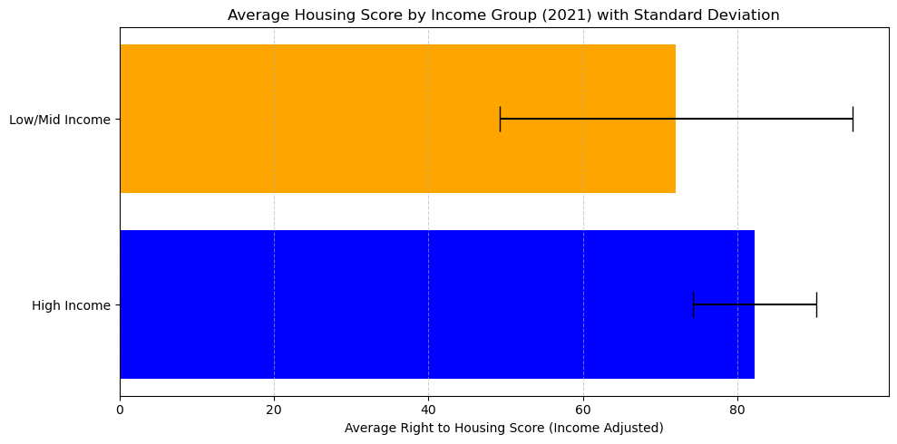

```python
# Now, we are interested in the average housing scores for high-income and low/mid-income countries in 2021.
# We will create a horizontal bar plot with error bars to visualize the average housing scores and the score standard deviations for each income group.

### Step 1: Create summary_stats that calculate average housing scores and standard deviations for each income group
summary_stats = housing_2021.groupby('Income_Group')['Housing_Score'].agg(['mean', 'std']).reset_index()

# Step 2: Create and plot horizontal bar plot with error bars
plt.figure(figsize=(10, 5))
plt.barh(
    summary_stats['Income_Group'],          # y-axis categories
    summary_stats['mean'],                 # bar lengths (mean scores)
    xerr=summary_stats['std'],             # error bars (standard deviation)
    capsize=10,                            # size of error bar caps
    color=['blue', 'orange']               # color by group
)

# Step 3: Formatting with labels, title, and grid
plt.xlabel("Average Right to Housing Score (Income Adjusted)")
plt.title("Average Housing Score by Income Group (2021) with Standard Deviation")
plt.grid(axis='x', linestyle='--', alpha=0.6)
plt.tight_layout()
plt.show()
```

- Here, we can see that high-income countries have a higher average housing score compared to low/mid-income countries.
- However, low/mid-income countries show a wider range of housing scores, which connects with the positive GDP/housing score relationship we observed earlier.

### Summary: even though High Income countries have higher average housing scores, low/mid-income countries show a statistically significant positive relationship between GDP and housing scores, indicating a constant improvement in housing scores as GDP increases.

### Subsection 3: The relationship between educational rights and GDP

- Introduction:

Education is a fundamental human right and a key driver of social and economic development. However, the quality and accessibility of education can vary significantly across countries, often influenced by economic factors such as GDP per capita. In this analysis, we aim to explore the relationship between a country's wealth and its ability to provide educational rights. Specifically, we seek to answer the question: "Do wealthier countries provide significantly better educational rights?"

- Question: Do wealthier countries provide significantly better educational rights?

By examining education scores and GDP per capita across countries, we hope to uncover whether wealthier nations consistently outperform lower-income countries in providing quality education. This analysis will also highlight disparities between income groups and regions, offering insights into how economic resources impact educational outcomes. Ultimately, the findings may inform policy recommendations for improving educational rights in less affluent nations.

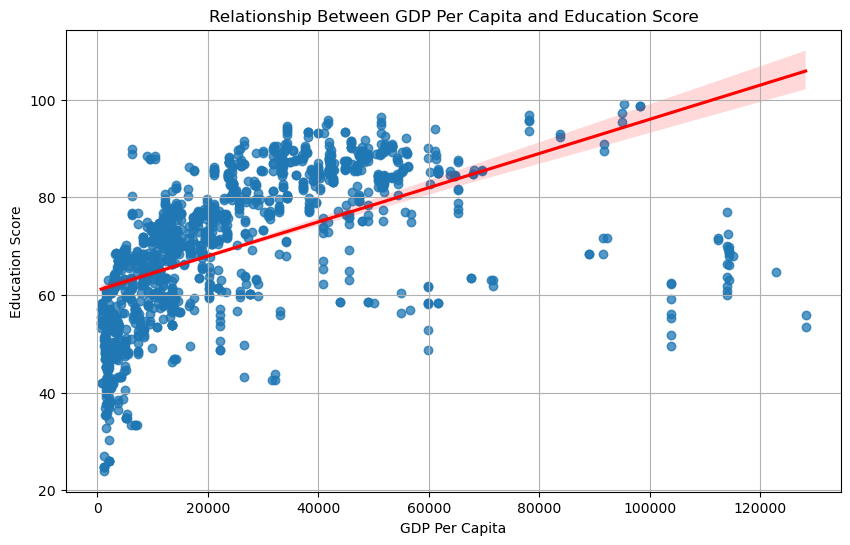

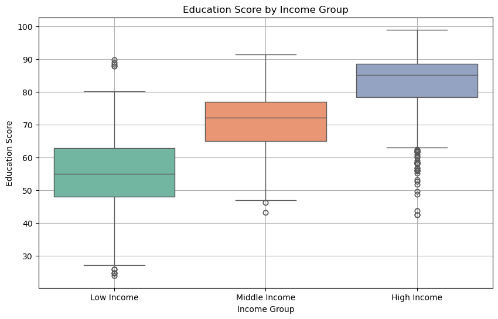

```python
# Extract relevant columns
New_Low_Mid_Income_Global = Low_Mid_Income_Global [['Country', 'Year', 'LMY_Education_All_GBScore', 'H_EducQual_All_MRGDP']]
New_High_Income_Global = High_Income_Global[['Country', 'Year', 'HiY_Education_All_GBScore', 'PISAmath_All_MRGDP']]

# Rename columns for consistency
New_Low_Mid_Income_Global .rename(columns={'LMY_Education_All_GBScore': 'Education_Score', 'H_EducQual_All_MRGDP': 'GDP'}, inplace=True)
New_High_Income_Global.rename(columns={'HiY_Education_All_GBScore': 'Education_Score', 'PISAmath_All_MRGDP': 'GDP'}, inplace=True)

# Combine the datasets
data = pd.concat([New_Low_Mid_Income_Global, New_Low_Mid_Income_Global], ignore_index=True)

# Drop rows with missing values
data = data.dropna()

# Step 2: Scatter Plot with Trendline
plt.figure(figsize=(10, 6))
sns.regplot(x='GDP', y='Education_Score', data=data, scatter_kws={'alpha': 0.5}, line_kws={'color': 'red'})
plt.xlabel('GDP Per Capita')
plt.ylabel('Education Score')
plt.title('Relationship Between GDP Per Capita and Education Score')
plt.grid(True)
plt.show()

# Step 3: Categorize countries into income groups
def categorize_income(gdp):
    if gdp < 10000:
        return 'Low Income'
    elif gdp < 30000:
        return 'Middle Income'
    else:
        return 'High Income'

data['Income_Group'] = data['GDP'].apply(categorize_income)

# Step 4: Boxplot for Income Groups
plt.figure(figsize=(10, 6))
sns.boxplot(x='Income_Group', y='Education_Score', data=data, palette='Set2')
plt.xlabel('Income Group')
plt.ylabel('Education Score')
plt.title('Education Score by Income Group')
plt.grid(True)
plt.show()
```

- Scatter Plot: The scatter plot shows a positive relationship between GDP per capita and education scores. Countries with higher GDP per capita tend to have better education scores, as indicated by the upward trendline.
- Box Plot: The boxplot reveals that high-income countries have significantly higher education scores compared to low- and middle-income countries. The spread of education scores is narrower for high-income countries, indicating more consistent performance in providing educational rights.